# week2_exercise

2022-04-29

```r
library(readr)        # to import tabular data (e.g. csv)
library(dplyr)        # to manipulate (tabular) data
library(ggplot2)      # to visualize data
library(sf)           # to handle spatial vector data
library(terra)        # To handle raster data
library(lubridate)    # To handle dates and times
```

```r
wildschwein_BE <- read_delim("wildschwein_BE_2056.csv",",")

wildschwein_BE <- st_as_sf(wildschwein_BE, coords = c("E", "N"), crs = 2056, remove = FALSE)
```

Task 2: Getting an overview

```r
wildschwein_BE <- group_by(wildschwein_BE, TierID)
wildschwein_BE <- mutate(wildschwein_BE,timelag = as.integer(difftime(lead(DatetimeUTC),DatetimeUTC, units = "secs")))

wildschwein_BE
```

```
## Simple feature collection with 51246 features and 7 fields
## Geometry type: POINT
## Dimension:     XY
## Bounding box:  xmin: 2568153 ymin: 1202306 xmax: 2575154 ymax: 1207609
## Projected CRS: CH1903+ / LV95
## # A tibble: 51,246 x 8
## # Groups:   TierID [3]
##    TierID TierName CollarID DatetimeUTC                E        N
##  * <chr>  <chr>       <dbl> <dttm>                 <dbl>    <dbl>
##  1 002A   Sabi        12275 2014-08-22 21:00:12 2570409. 1204752.
##  2 002A   Sabi        12275 2014-08-22 21:15:16 2570402. 1204863.
##  3 002A   Sabi        12275 2014-08-22 21:30:43 2570394. 1204826.
##  4 002A   Sabi        12275 2014-08-22 21:46:07 2570379. 1204817.
##  5 002A   Sabi        12275 2014-08-22 22:00:22 2570390. 1204818.
##  6 002A   Sabi        12275 2014-08-22 22:15:10 2570390. 1204825.
##  7 002A   Sabi        12275 2014-08-22 22:30:13 2570387. 1204831.
##  8 002A   Sabi        12275 2014-08-22 22:45:11 2570381. 1204840.
##  9 002A   Sabi        12275 2014-08-22 23:00:27 2570316. 1204935.
## 10 002A   Sabi        12275 2014-08-22 23:15:41 2570393. 1204815.
## # ... with 51,236 more rows, and 2 more variables: geometry <POINT [m]>,
## #   timelag <int>
```

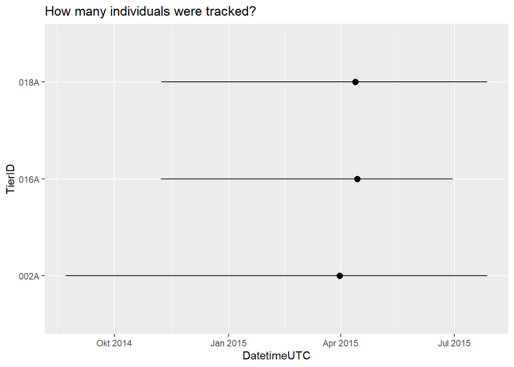

```r
ggplot(data = wildschwein_BE) +
  stat_summary(
    mapping = aes(x = DatetimeUTC, y = TierID),
    fun.min = min,
    fun.max = max,
    fun = median) +
  ggtitle("How many individuals were tracked?")
```

Three individuals were tracked Sabi, Rosa and Ruth.The plot shows for how long they were tracked.

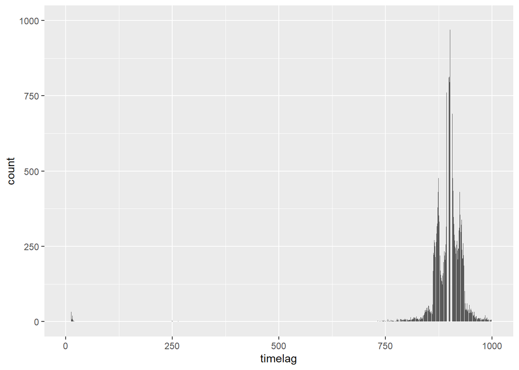

```r
ggplot(wildschwein_BE, aes(timelag)) +
  geom_bar(stat = "count") +
  xlim(0,1000) +
  ylim(0,1000)
```

All individuals were tracked more or less concurrently and sometimes sequentially.

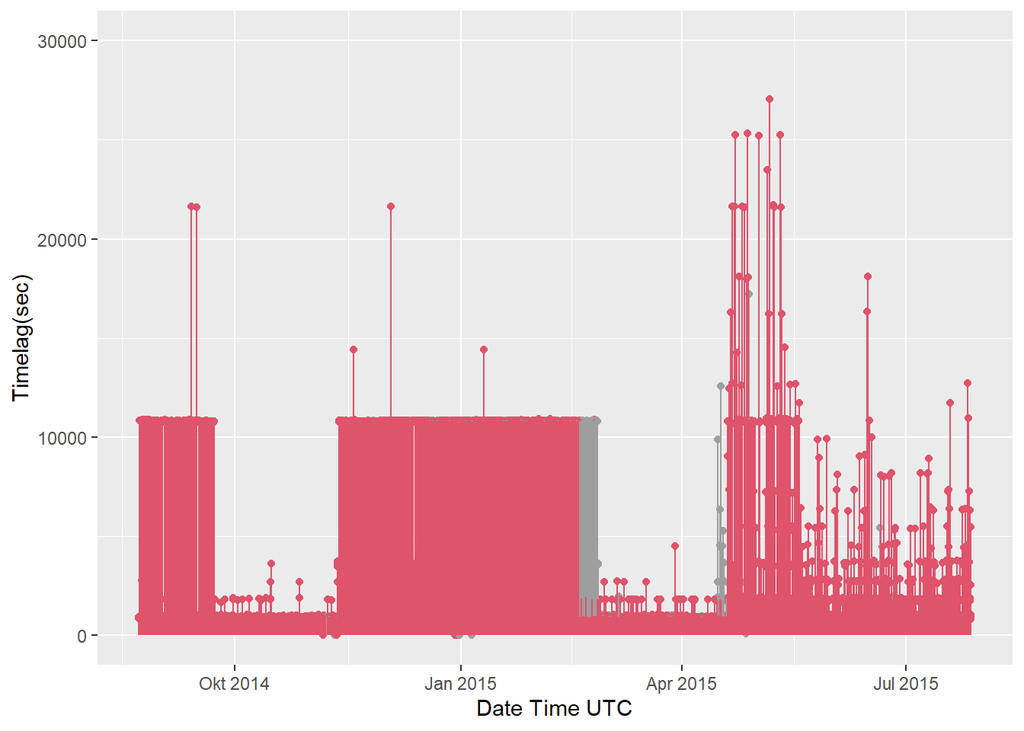

```r
ggplot(wildschwein_BE, aes(x= wildschwein_BE$DatetimeUTC, y= wildschwein_BE$timelag)) +
  geom_point(color=wildschwein_BE$TierID) +
  geom_segment( aes(x= DatetimeUTC, xend= DatetimeUTC, y=0, yend= timelag, color = wildschwein_BE$TierID),
                color=wildschwein_BE$TierID) +
  ylim(0,30000) +
  labs(x="Date Time UTC", y="Timelag(sec)", color = "Tier ID")
```

```r
#I tried to add a Color Legend with the TierID here. Unfortunately, I don't really get it how I have to do it.
```

Task 3:

```r
wildschwein_BE <- mutate(wildschwein_BE,steplength = (sqrt((E-lead(E))^2 + (N-lead(N))^2)))
```

```r
wildschwein_BE <- mutate(wildschwein_BE, speed = ((steplength/timelag)))
```

The speed unit is in m/s.

Task 4:

```r
caro <- read_delim("caro60.csv",",")
caro <- st_as_sf(caro, coords = c("E", "N"), crs = 2056, remove = FALSE)
```

```r
caro_3 = caro[seq(1, nrow(caro), 3), ]
caro_6 = caro[seq(1, nrow(caro), 6), ]
caro_9 = caro[seq(1, nrow(caro), 9), ]

nrow(caro)
```

```
## [1] 200
```

```r
nrow(caro_3)
```

```
## [1] 67
```

```r
nrow(caro_6)
```

```
## [1] 34
```

```r
nrow(caro_9)
```

```
## [1] 23
```

Calculating timelag for all the datasets:

```r
caro <- group_by(caro, TierID)
caro <- mutate(caro,timelag = as.integer(difftime(lead(DatetimeUTC), DatetimeUTC, units = "secs")))

caro_3 <- group_by(caro_3, TierID)
caro_3 <- mutate(caro_3,timelag = as.integer(difftime(lead(DatetimeUTC),DatetimeUTC, units = "secs")))

caro_6 <- group_by(caro_6, TierID)
caro_6 <- mutate(caro_6,timelag = as.integer(difftime(lead(DatetimeUTC),DatetimeUTC, units = "secs")))

caro_9 <- group_by(caro_9, TierID)
caro_9 <- mutate(caro_9,timelag = as.integer(difftime(lead(DatetimeUTC),DatetimeUTC, units = "secs")))
```

Calculating step length for all the data sets:

```r
caro <- mutate(caro,steplength = (sqrt((E-lead(E))^2 + (N-lead(N))^2)))

caro_3 <- mutate(caro_3,steplength = (sqrt((E-lead(E))^2 + (N-lead(N))^2)))

caro_6 <- mutate(caro_6,steplength = (sqrt((E-lead(E))^2 + (N-lead(N))^2)))

caro_9 <- mutate(caro_9,steplength = (sqrt((E-lead(E))^2 + (N-lead(N))^2)))
```

Calculating speed for all data sets:

```r
caro <- mutate(caro, speed = (steplength/timelag))

caro_3 <- mutate(caro_3, speed = (steplength/timelag))

caro_6 <- mutate(caro_6, speed = (steplength/timelag))

caro_9 <- mutate(caro_9, speed = (steplength/timelag))
```

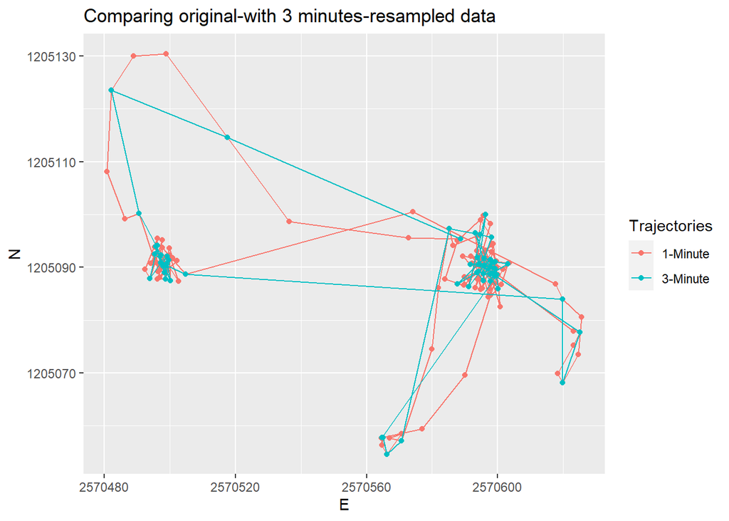

```r
first_plot <- ggplot() +
  geom_path(data = caro, aes(x = E, y = N, colour = "1-Minute")) +
  geom_point(data = caro, aes(x=E, y=N, colour = "1-Minute")) +
  geom_path(data = caro_3,aes(x = E, y = N, colour = "3-Minute")) +
  geom_point(data = caro_3, aes(x=E, y=N, colour = "3-Minute")) +
  guides(colour= guide_legend(title = "Trajectories")) +
  ggtitle("Comparing original-with 3 minutes-resampled data")

first_plot
```

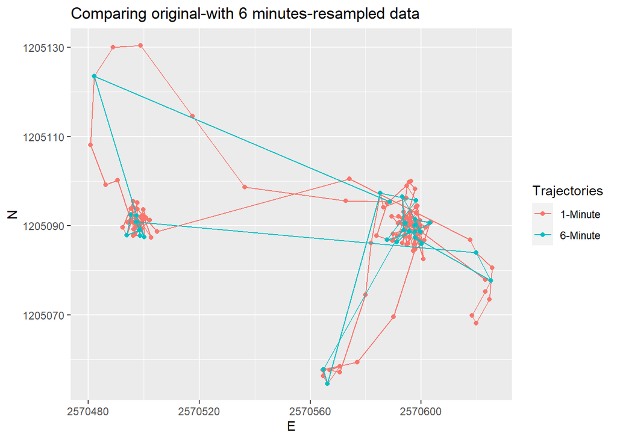

```r
second_plot <- ggplot() +
  geom_path(data = caro, aes(x = E, y = N, colour = "1-Minute")) +
  geom_point(data = caro, aes(x=E, y=N, colour = "1-Minute")) +
  geom_path(data = caro_6,aes(x = E, y = N, colour = "6-Minute")) +
  geom_point(data = caro_6, aes(x=E, y=N, colour = "6-Minute")) +
  guides(colour= guide_legend(title = "Trajectories")) +
  ggtitle("Comparing original-with 6 minutes-resampled data")

second_plot
```

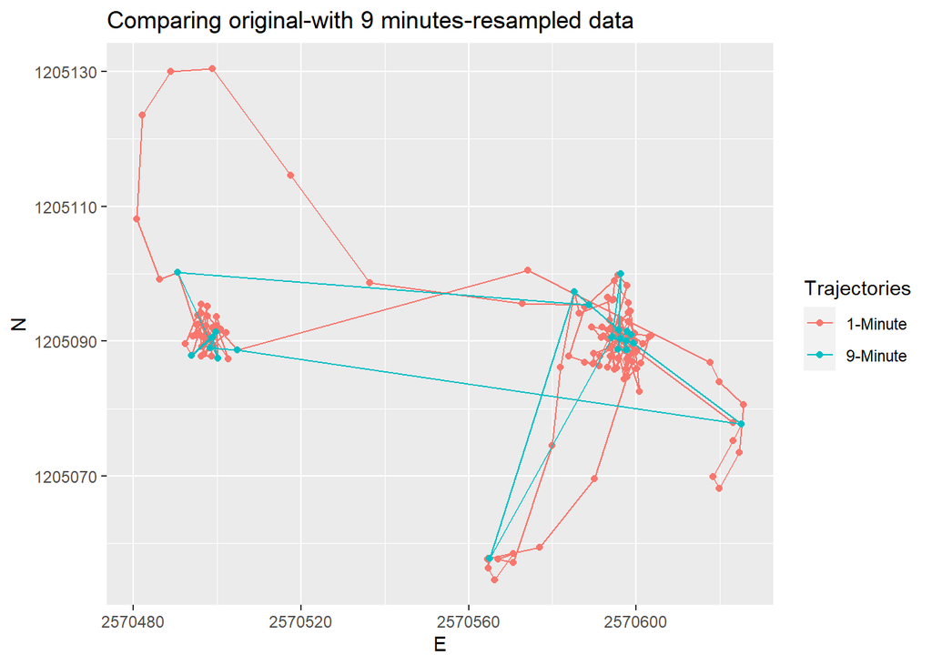

```r
third_plot <- ggplot() +
  geom_path(data = caro, aes(x = E, y = N, colour = "1-Minute")) +
  geom_point(data = caro, aes(x=E, y=N, colour = "1-Minute")) +
  geom_path(data = caro_9,aes(x = E, y = N, colour = "9-Minute")) +
  geom_point(data = caro_9, aes(x=E, y=N, colour = "9-Minute")) +
  guides(colour= guide_legend(title = "Trajectories")) +
  ggtitle("Comparing original-with 9 minutes-resampled data")

third_plot
```

Comparing the original data trajectories to the three resampled data shows how the trajectories vary depending on the measured data.The “3-Minute” and “6-Minute” trajectories are almost projecting the same path. But the “9-Minute” trajectory shows a different and a superficiel path. Compared to the “1-Minute” trajectory the “3-Minute” trajectory is most similar and the “9-Minute” trajectory misses many important measurements. To conclude is, as we have seen in the lectures, it is not easy to decide which scale/granularity is sufficient to capture the character of a movement path (Lecture slides_Data issues, 51).

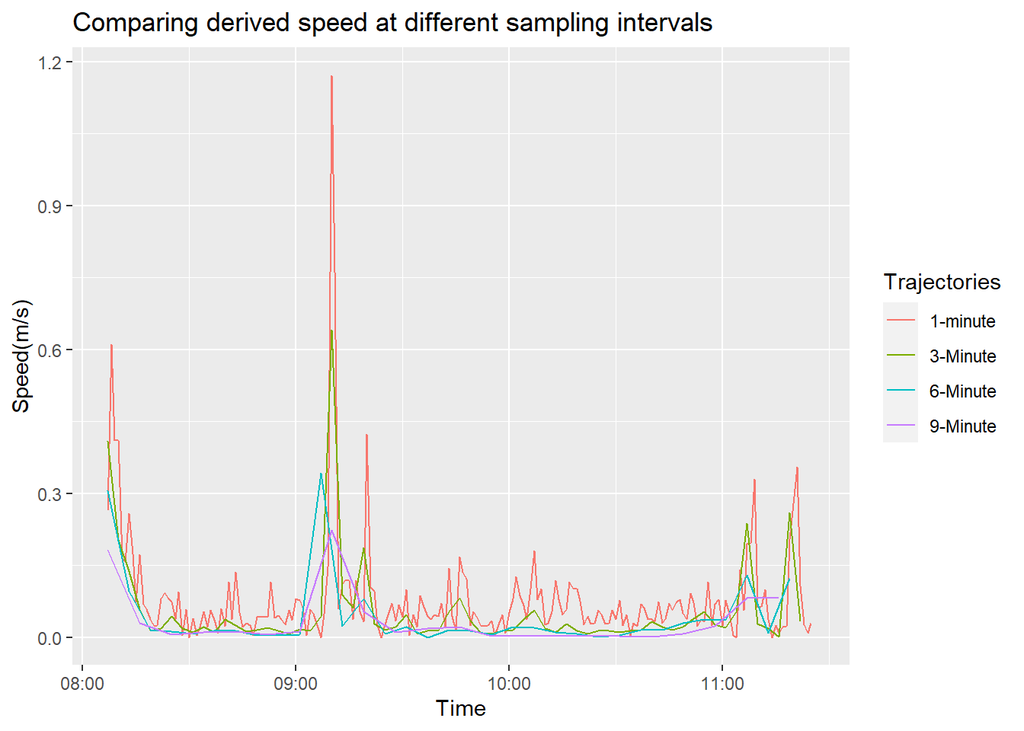

```r
fourth_plot <- ggplot() +
  geom_path(data = caro, aes(x = DatetimeUTC, y = speed, colour = "1-minute")) +
  geom_path(data = caro_3, aes(x=DatetimeUTC, y= speed, colour = "3-Minute")) +
  geom_path(data = caro_6,aes(x = DatetimeUTC, y = speed, colour = "6-Minute")) +
  geom_path(data = caro_9, aes(x=DatetimeUTC, y= speed, colour = "9-Minute")) +
  guides(colour= guide_legend(title = "Trajectories")) +
  ggtitle("Comparing derived speed at different sampling intervals") +
  xlab("Time") + ylab("Speed(m/s)")

fourth_plot
```

This plot shows how detailed the 1-minute trajectory is and how the 3-, 6- & 9-minute summarized the data differently. Again one can see that trajectory 3-minute includes the main details from 1-minute trajectory and the 6- and 9-minute trajectories show a smoother path.

Task 5:

```r
library(zoo)
```

```r
example <- rnorm(10)
rollmean(example, k=3, fill = NA, align = "left")
```

```
##  [1]  0.2194090  0.2174855  0.3394327  0.2580391 -0.6350116 -0.8147261
##  [7] -1.1423882 -0.7640306         NA         NA
```

```r
rollmean(example, k=5, fill = NA, align = "right")
```

```
##  [1]          NA          NA          NA          NA  0.43328108  0.03985215
##  [7] -0.23352040 -0.18719999 -0.77607207 -0.89559838
```

```r
rollmean(example, k=2, fill = NA, align = "left")
```

```
##  [1]  0.5740536 -0.2874282  0.3687164  0.7540892 -0.2265979 -1.0929501
##  [7] -0.8550586 -0.9876628 -1.0169068         NA
```

```r
caro_rm5 <- rollmean(caro$speed, k=5, fill = NA, align = "right")
caro_rm10 <-rollmean(caro$speed, k=10, fill = NA, align = "right")
```

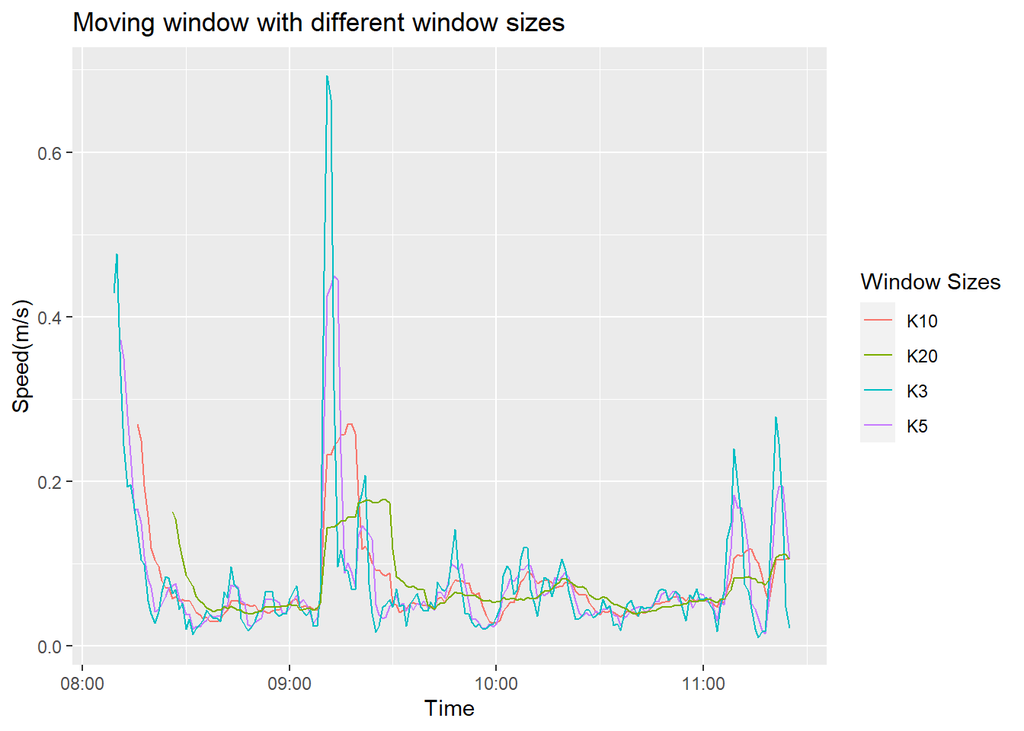

```r
fifth_plot <- ggplot(caro, aes(x = DatetimeUTC, y = speed)) +
  geom_path(aes(y = rollmean(speed, 10, align = "right", fill = NA), colour = "K10")) +
  geom_path(aes(y = rollmean(speed, 5, align = "right", fill = NA), colour = "K5")) +
  geom_path(aes(y = rollmean(speed, 3, align = "right", fill = NA), colour = "K3")) +
  geom_path(aes(y = rollmean(speed, 20, align = "right", fill = NA), colour = "K20")) +
   guides(colour= guide_legend(title = "Window Sizes")) +
  ggtitle("Moving window with different window sizes") +
  xlab("Time") + ylab("Speed(m/s)")

fifth_plot
```